# Reproducible Research (Project 1)

Oyhx

29/05/2018

Load Packages

```r
library(ggplot2)
library(dplyr)
```

## Loading the Data

```r
activity <- read.csv("activity.csv", stringsAsFactors = FALSE)
```

## What is mean total number of steps taken per day?

```r
dailyactivity <- activity %>%
  group_by(date) %>%
  summarise(tot_steps= sum(steps), mean_steps = mean(steps), med_steps = median(steps))
```

The total, mean and median number of steps is indicated below.

```r
print(dailyactivity)
```

```
## # A tibble: 61 x 4
##    date       tot_steps mean_steps med_steps
##    <chr>          <int>      <dbl>     <dbl>
##  1 2012-10-01        NA     NA           NA
##  2 2012-10-02       126      0.438        0.
##  3 2012-10-03     11352     39.4          0.
##  4 2012-10-04     12116     42.1          0.
##  5 2012-10-05     13294     46.2          0.
##  6 2012-10-06     15420     53.5          0.
##  7 2012-10-07     11015     38.2          0.
##  8 2012-10-08        NA     NA           NA
##  9 2012-10-09     12811     44.5          0.
## 10 2012-10-10      9900     34.4          0.
## # ... with 51 more rows
```

## Histogram of the total number of steps taken each day

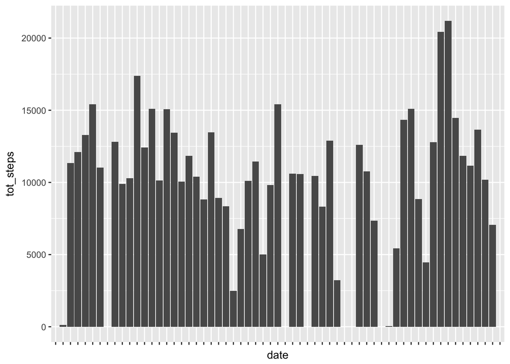

```r
ggplot(data= dailyactivity, aes(x=date, y=tot_steps), na.rm = TRUE) + geom_histogram(stat = "identity") + theme(
  axis.text.x = element_blank())
```

What is the average daily activity pattern?

Make a time series plot (i.e. type = “l”) of the 5-minute interval (x-axis) and the average number of steps taken, averaged across all days (y-axis)

Which 5-minute interval, on average across all the days in the dataset, contains the maximum number of steps?

```r
intervalactivity <- activity %>%
  group_by(interval) %>%
  summarise(tot_intsteps= sum(steps, na.rm = TRUE), mean_intsteps = mean(steps, na.rm = TRUE), med_intsteps = median(steps, na.rm = TRUE))
```

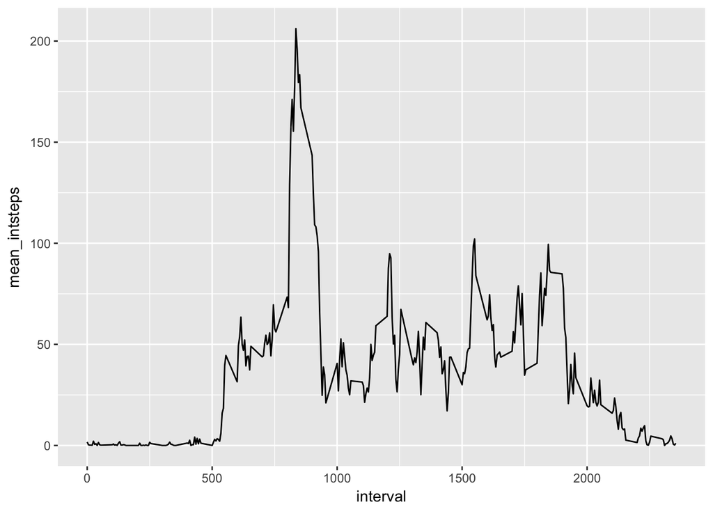

```r
ggplot(data= intervalactivity, aes(x=interval, y=mean_intsteps)) +geom_line()
```

The five minute interval with the highest mean number of steps is 0835.

## Calculate and report the total number of missing values in the dataset (i.e. the total number of rows with NAs)

```r
activity %>%
  select(steps, date, interval) %>%  # replace to your needs
  summarise_all(funs(sum(is.na(.))))
```

```
##   steps date interval
## 1  2304    0        0
```

## Replace NA values using mean value for interval

```r
activity1 <- activity
library(plyr)
impute.mean <- function (x) replace (x, is.na(x), mean (x, na.rm = TRUE))
activity1 <- ddply(activity1, ~interval, transform, steps = impute.mean(steps))
```

```r
detach(package:plyr)
```

## Daily Plot of updated total number of steps

```r
dailyactivity1 <- activity1 %>%
  group_by(date) %>%
  summarise(tot_steps1= sum(steps), mean_steps1 = mean(steps), med_steps1 = median(steps))
```

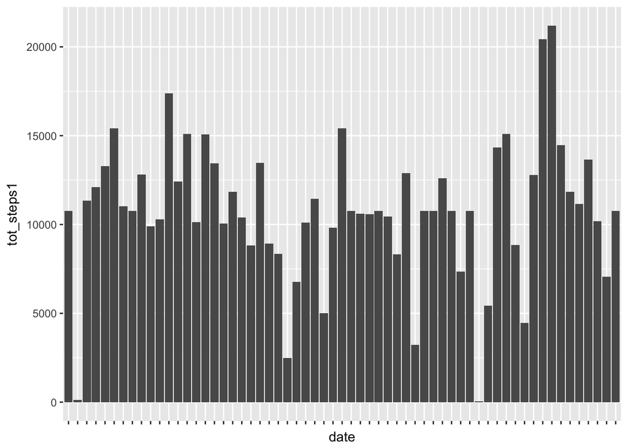

```r
ggplot(data= dailyactivity1, aes(x=date, y=tot_steps1), na.rm = TRUE) + geom_histogram(stat = "identity") + theme(
  axis.text.x = element_blank())
```

## Comparing mean and median between original and updated dataset (activity vs activity1)

```r
mean(activity$steps, na.rm = TRUE) - mean(activity1$steps)
```

```
## [1] 0
```

```r
median(activity$steps, na.rm = TRUE) - median(activity1$steps)
```

```
## [1] 0
```

There is no difference in mean and median number of steps between both datasets.

## Are there differences in activity patterns between weekdays and weekends?

Convert the date from character to date data type before using the weekday function.

```r
activity1$date <- as.Date(activity1$date)
```

```r
activity1$daytype <- weekdays(activity1$date)
```

```r
activity1$grouped <- ifelse((activity1$daytype == "Saturday"| activity1$daytype == "Sunday"), "Weekend", "Weekday")
```

```r
meanact1 <- activity1 %>%
  group_by(grouped, interval) %>%
  summarise(avgsteps = mean(steps))
```

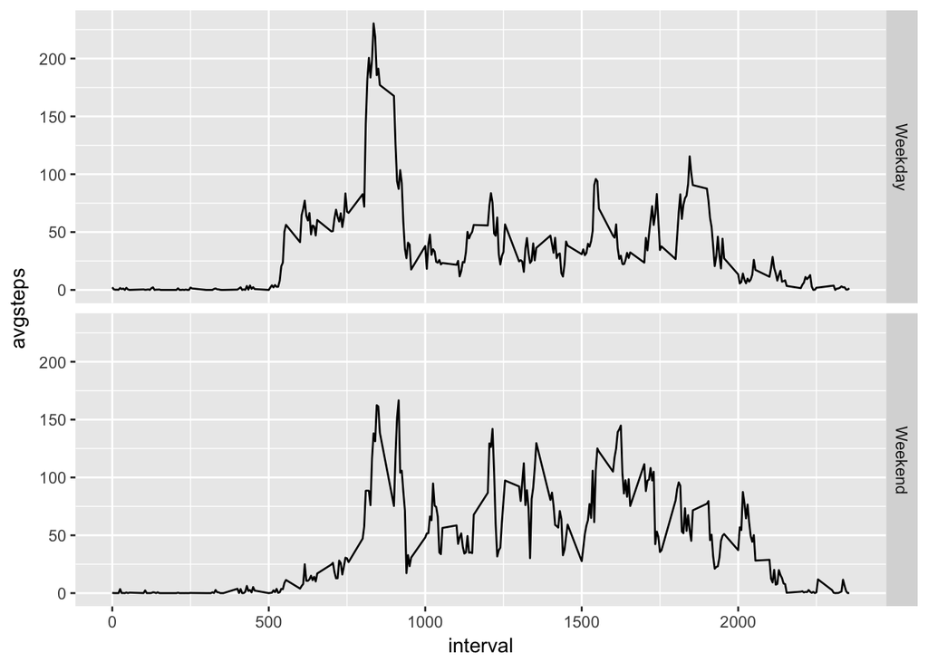

```r
ggplot(data =meanact1, aes(x=interval, y=avgsteps)) +geom_line() +facet_grid(grouped ~.)
```